# Report for metaxas_recent

## 1. The Data

Here is your dataset as we reprocessed it. Please take a look.

**Click to see the clean data**

```r
#
 study_data |>
          kable( format = "html") %>%
          kable_styling(position = "center", full_width = F, bootstrap_options = c("striped","hover"))%>%
          scroll_box( width = "1000px", height = "500px", fixed_thead = T)
```

| Entry | Study | Region | Site | Depth.m | Sample.Year | Sample.Month | Sample.Day | Latitude | Longitude | Taxon | Fixed.or.Random | Sample.Unit.Size.sq.m | Percent.Cover | Stipe.Density.num.per.sq.m | Individual.Density.num.per.sq.m | Biomass.kg.wet.per.sq.m |
| --- | --- | --- | --- | --- | --- | --- | --- | --- | --- | --- | --- | --- | --- | --- | --- | --- |
| 1 | metaxas_recent | Scotian Shelf | Halibut I | 7.5 | 2018 | 10 | NA | 44.88797 | -62.20700 | Agarum clathratum | Fixed | 0.3125 | NA | 0.0000000 | 0.0000000 | NA |
| 2 | metaxas_recent | Scotian Shelf | Halibut I | 7.5 | 2018 | 10 | NA | 44.88797 | -62.20700 | Alaria esculenta | Fixed | 0.3125 | NA | 0.0000000 | 0.0000000 | NA |
| 3 | metaxas_recent | Scotian Shelf | Halibut I | 7.5 | 2018 | 10 | NA | 44.88797 | -62.20700 | Laminaria digitata | Fixed | 0.3125 | NA | 14.0000000 | 14.0000000 | NA |
| 4 | metaxas_recent | Scotian Shelf | Halibut I | 7.5 | 2018 | 10 | NA | 44.88797 | -62.20700 | Saccharina latissima | Fixed | 0.3125 | NA | 2.8333333 | 2.8333333 | NA |
| 5 | metaxas_recent | Scotian Shelf | Halibut I | 7.5 | 2018 | 10 | NA | 44.88797 | -62.20700 | Saccorhiza dermatodea | Fixed | 0.3125 | NA | 0.0000000 | 0.0000000 | NA |
| 6 | metaxas_recent | Scotian Shelf | Tuffin I | 7.5 | 2018 | 10 | NA | 44.90660 | -62.15593 | Agarum clathratum | Fixed | 0.2500 | NA | 0.0000000 | 0.0000000 | NA |
| 7 | metaxas_recent | Scotian Shelf | Tuffin I | 7.5 | 2018 | 10 | NA | 44.90660 | -62.15593 | Alaria esculenta | Fixed | 0.2500 | NA | 0.0000000 | 0.0000000 | NA |
| 8 | metaxas_recent | Scotian Shelf | Tuffin I | 7.5 | 2018 | 10 | NA | 44.90660 | -62.15593 | Laminaria digitata | Fixed | 0.2500 | NA | 30.9090909 | 30.9090909 | NA |
| 9 | metaxas_recent | Scotian Shelf | Tuffin I | 7.5 | 2018 | 10 | NA | 44.90660 | -62.15593 | Saccharina latissima | Fixed | 0.2500 | NA | 0.7272727 | 0.7272727 | NA |
| 10 | metaxas_recent | Scotian Shelf | Tuffin I | 7.5 | 2018 | 10 | NA | 44.90660 | -62.15593 | Saccorhiza dermatodea | Fixed | 0.2500 | NA | 0.0000000 | 0.0000000 | NA |
| 11 | metaxas_recent | Scotian Shelf | The Moll | 7.5 | 2018 | 10 | NA | 44.92397 | -62.23767 | Agarum clathratum | Fixed | 0.5000 | NA | 0.0000000 | 0.0000000 | NA |
| 12 | metaxas_recent | Scotian Shelf | The Moll | 7.5 | 2018 | 10 | NA | 44.92397 | -62.23767 | Alaria esculenta | Fixed | 0.5000 | NA | 0.0000000 | 0.0000000 | NA |
| 13 | metaxas_recent | Scotian Shelf | The Moll | 7.5 | 2018 | 10 | NA | 44.92397 | -62.23767 | Laminaria digitata | Fixed | 0.5000 | NA | 5.6000000 | 5.6000000 | NA |
| 14 | metaxas_recent | Scotian Shelf | The Moll | 7.5 | 2018 | 10 | NA | 44.92397 | -62.23767 | Saccharina latissima | Fixed | 0.5000 | NA | 3.2000000 | 3.2000000 | NA |
| 15 | metaxas_recent | Scotian Shelf | The Moll | 7.5 | 2018 | 10 | NA | 44.92397 | -62.23767 | Saccorhiza dermatodea | Fixed | 0.5000 | NA | 0.0000000 | 0.0000000 | NA |
| 16 | metaxas_recent | Scotian Shelf | Shag Rock | 6.0 | 2019 | 7 | NA | 44.43128 | -63.56650 | Agarum clathratum | Fixed | 0.5000 | 0.0000000 | 0.0000000 | 0.0000000 | NA |
| 17 | metaxas_recent | Scotian Shelf | Shag Rock | 6.0 | 2019 | 7 | NA | 44.43128 | -63.56650 | Alaria esculenta | Fixed | 0.5000 | 0.0000000 | 0.0000000 | 0.0000000 | NA |
| 18 | metaxas_recent | Scotian Shelf | Shag Rock | 6.0 | 2019 | 7 | NA | 44.43128 | -63.56650 | Laminaria digitata | Fixed | 0.5000 | 70.5137845 | 23.3333333 | 23.3333333 | NA |
| 19 | metaxas_recent | Scotian Shelf | Shag Rock | 6.0 | 2019 | 7 | NA | 44.43128 | -63.56650 | Saccharina latissima | Fixed | 0.5000 | 19.9973147 | 6.3333333 | 6.3333333 | NA |
| 20 | metaxas_recent | Scotian Shelf | Shag Rock | 6.0 | 2019 | 7 | NA | 44.43128 | -63.56650 | Saccorhiza dermatodea | Fixed | 0.5000 | 0.0000000 | 0.0000000 | 0.0000000 | NA |
| 21 | metaxas_recent | Scotian Shelf | Shag Rock | 9.0 | 2019 | 7 | NA | 44.43128 | -63.56650 | Agarum clathratum | Fixed | 0.5000 | 0.0000000 | 0.0000000 | 0.0000000 | NA |
| 22 | metaxas_recent | Scotian Shelf | Shag Rock | 9.0 | 2019 | 7 | NA | 44.43128 | -63.56650 | Alaria esculenta | Fixed | 0.5000 | 0.0000000 | 0.0000000 | 0.0000000 | NA |
| 23 | metaxas_recent | Scotian Shelf | Shag Rock | 9.0 | 2019 | 7 | NA | 44.43128 | -63.56650 | Laminaria digitata | Fixed | 0.5000 | 42.7796951 | 3.3333333 | 3.3333333 | NA |
| 24 | metaxas_recent | Scotian Shelf | Shag Rock | 9.0 | 2019 | 7 | NA | 44.43128 | -63.56650 | Saccharina latissima | Fixed | 0.5000 | 21.9297390 | 11.3333333 | 11.3333333 | NA |
| 25 | metaxas_recent | Scotian Shelf | Shag Rock | 9.0 | 2019 | 7 | NA | 44.43128 | -63.56650 | Saccorhiza dermatodea | Fixed | 0.5000 | 0.0000000 | 0.0000000 | 0.0000000 | NA |
| 26 | metaxas_recent | Scotian Shelf | Speck I | 6.0 | 2019 | 7 | NA | 44.84490 | -62.38682 | Agarum clathratum | Fixed | 1.0000 | 0.0000000 | 0.0000000 | 0.0000000 | NA |
| 27 | metaxas_recent | Scotian Shelf | Speck I | 6.0 | 2019 | 7 | NA | 44.84490 | -62.38682 | Alaria esculenta | Fixed | 1.0000 | 0.0000000 | 0.0000000 | 0.0000000 | NA |
| 28 | metaxas_recent | Scotian Shelf | Speck I | 6.0 | 2019 | 7 | NA | 44.84490 | -62.38682 | Laminaria digitata | Fixed | 1.0000 | 5.9389140 | 0.7272727 | 0.7272727 | NA |
| 29 | metaxas_recent | Scotian Shelf | Speck I | 6.0 | 2019 | 7 | NA | 44.84490 | -62.38682 | Saccharina latissima | Fixed | 1.0000 | 10.8031674 | 2.7272727 | 2.7272727 | NA |
| 30 | metaxas_recent | Scotian Shelf | Speck I | 6.0 | 2019 | 7 | NA | 44.84490 | -62.38682 | Saccorhiza dermatodea | Fixed | 1.0000 | 0.0000000 | 0.0000000 | 0.0000000 | NA |

[output cut: 925 more lines]

Here is your dataset as where we have now summed across all kelp species and put into the KelpTime main database format.

**Click to see the data in kelptime format**

```r
#|
kelptime_study |>
         kable( format = "html") %>%
         kable_styling(position = "center", full_width = F, bootstrap_options = c("striped","hover"))%>%
         scroll_box( width = "1000px", height = "500px", fixed_thead = T)
```

| study | site | period | latitude | longitude | sample_unit_size_sq_m | sasdate | max_depth | mean_depth | min_depth | biomass_kg_wet_per_sq_m | stipe_density_num_per_sq_m | individual_density_num_per_sq_m | percent_cover | has_bm | has_sd | has_id | has_pc | use_which | focalKelp | focalUnit | geometry | ecoregion | province | realm | focal_std_by_ecoregion | focal_std_by_province | focal_std_by_realm | ln_focal_std_by_ecoregion | ln_focal_std_by_province | … |
| --- | --- | --- | --- | --- | --- | --- | --- | --- | --- | --- | --- | --- | --- | --- | --- | --- | --- | --- | --- | --- | --- | --- | --- | --- | --- | --- | --- | --- | --- | --- |
| metaxas_recent | Halibut I | 1 | 44.88797 | -62.20700 | 9999.0000 | 2018-08-15 | 9 | 7.5 | 6 | NA | NA | NA | 80.966523 | 0 | 65 | 65 | 79 | 4 | 80.966523 | Percent cover | c(-62.207, 44.887967) | Scotian Shelf | Cold Temperate Northwest Atlantic | Temperate Northern Atlantic | 0.8710873 | 0.3248822 | 0.3248822 | -0.1265986 | -1.0939765 | … |
| metaxas_recent | Halibut I | 3 | 44.88797 | -62.20700 | 0.5000 | 2019-07-15 | 9 | 7.5 | 6 | NA | 21.090909 | 21.090909 | 80.957706 | 0 | 65 | 65 | 79 | 4 | 80.957706 | Percent cover | c(-62.207, 44.88797) | Scotian Shelf | Cold Temperate Northwest Atlantic | Temperate Northern Atlantic | 0.8709924 | 0.3248468 | 0.3248468 | -0.1267063 | -1.0940821 | … |
| metaxas_recent | Halibut I | 4 | 44.88797 | -62.20700 | 0.5000 | 2019-10-15 | 9 | 7.5 | 6 | NA | 14.666667 | 14.666667 | 72.150350 | 0 | 65 | 65 | 79 | 4 | 72.150350 | Percent cover | c(-62.207, 44.88797) | Scotian Shelf | Cold Temperate Northwest Atlantic | Temperate Northern Atlantic | 0.7762375 | 0.2895069 | 0.2895069 | -0.2404964 | -1.2056180 | … |
| metaxas_recent | Halibut I | 5 | 44.88797 | -62.20700 | 0.5000 | 2020-07-15 | 9 | 7.5 | 6 | NA | 25.333333 | 25.333333 | 88.073980 | 0 | 65 | 65 | 79 | 4 | 88.073980 | Percent cover | c(-62.207, 44.88797) | Scotian Shelf | Cold Temperate Northwest Atlantic | Temperate Northern Atlantic | 0.9475536 | 0.3534012 | 0.3534012 | -0.0433736 | -1.0122478 | … |
| metaxas_recent | Halibut I | 6 | 44.88797 | -62.20700 | 0.5000 | 2020-10-15 | 9 | 7.5 | 6 | NA | 25.166667 | 25.166667 | 65.602679 | 0 | 65 | 65 | 79 | 4 | 65.602679 | Percent cover | c(-62.207, 44.88797) | Scotian Shelf | Cold Temperate Northwest Atlantic | Temperate Northern Atlantic | 0.7057936 | 0.2632340 | 0.2632340 | -0.3343634 | -1.2974267 | … |
| metaxas_recent | Halibut I | 7 | 44.88797 | -62.20700 | 0.4000 | 2021-07-15 | 9 | 7.5 | 6 | NA | 18.500000 | 18.500000 | 89.356737 | 0 | 65 | 65 | 79 | 4 | 89.356737 | Percent cover | c(-62.207, 44.88797) | Scotian Shelf | Cold Temperate Northwest Atlantic | Temperate Northern Atlantic | 0.9613543 | 0.3585483 | 0.3585483 | -0.0290640 | -0.9981834 | … |
| metaxas_recent | Halibut I | 8 | 44.88797 | -62.20700 | 0.5000 | 2021-10-15 | 9 | 7.5 | 6 | NA | 19.200000 | 19.200000 | 71.863308 | 0 | 65 | 65 | 79 | 4 | 71.863308 | Percent cover | c(-62.207, 44.88797) | Scotian Shelf | Cold Temperate Northwest Atlantic | Temperate Northern Atlantic | 0.7731493 | 0.2883551 | 0.2883551 | -0.2444319 | -1.2094709 | … |
| metaxas_recent | Halibut I | 9 | 44.88797 | -62.20700 | 0.5000 | 2022-07-15 | 9 | 7.5 | 6 | NA | 16.338462 | 16.338462 | 76.741071 | 0 | 65 | 65 | 79 | 4 | 76.741071 | Percent cover | c(-62.207, 44.88797) | Scotian Shelf | Cold Temperate Northwest Atlantic | Temperate Northern Atlantic | 0.8256273 | 0.3079274 | 0.3079274 | -0.1795726 | -1.1459324 | … |
| metaxas_recent | Halibut I | 10 | 44.88797 | -62.20700 | 0.5000 | 2022-10-15 | 9 | 7.5 | 6 | NA | 8.666667 | 8.666667 | 40.745342 | 0 | 65 | 65 | 79 | 4 | 40.745342 | Percent cover | c(-62.207, 44.88797) | Scotian Shelf | Cold Temperate Northwest Atlantic | Temperate Northern Atlantic | 0.4383632 | 0.1634927 | 0.1634927 | -0.8021515 | -1.7516197 | … |
| metaxas_recent | Long I | 1 | 44.88955 | -62.30292 | 9999.0000 | 2018-08-15 | 9 | 7.5 | 6 | NA | NA | NA | 26.622187 | 0 | 65 | 65 | 79 | 4 | 26.622187 | Percent cover | c(-62.302917, 44.88955) | Scotian Shelf | Cold Temperate Northwest Atlantic | Temperate Northern Atlantic | 0.2864177 | 0.1068228 | 0.1068228 | -1.2159855 | -2.1470966 | … |
| metaxas_recent | Long I | 2 | 44.88955 | -62.30292 | 4999.6250 | 2019-07-15 | 9 | 7.5 | 6 | NA | 7.428571 | 7.428571 | 30.494505 | 0 | 65 | 65 | 79 | 4 | 30.494505 | Percent cover | c(-62.30292, 44.88955) | Scotian Shelf | Cold Temperate Northwest Atlantic | Temperate Northern Atlantic | 0.3280785 | 0.1223607 | 0.1223607 | -1.0844772 | -2.0222244 | … |
| metaxas_recent | Long I | 3 | 44.88955 | -62.30292 | 0.5000 | 2019-10-15 | 9 | 7.5 | 6 | NA | 6.375000 | 6.375000 | 30.129870 | 0 | 65 | 65 | 79 | 4 | 30.129870 | Percent cover | c(-62.30292, 44.88955) | Scotian Shelf | Cold Temperate Northwest Atlantic | Temperate Northern Atlantic | 0.3241555 | 0.1208976 | 0.1208976 | -1.0961487 | -2.0333400 | … |
| metaxas_recent | Long I | 4 | 44.88955 | -62.30292 | 0.5000 | 2020-07-15 | 9 | 7.5 | 6 | NA | 6.416667 | 6.416667 | 51.643105 | 0 | 65 | 65 | 79 | 4 | 51.643105 | Percent cover | c(-62.30292, 44.88955) | Scotian Shelf | Cold Temperate Northwest Atlantic | Temperate Northern Atlantic | 0.5556080 | 0.2072205 | 0.2072205 | -0.5698539 | -1.5268422 | … |
| metaxas_recent | Long I | 5 | 44.88955 | -62.30292 | 0.2500 | 2020-10-15 | 9 | 7.5 | 6 | NA | 13.833333 | 13.833333 | 34.421060 | 0 | 65 | 65 | 79 | 4 | 34.421060 | Percent cover | c(-62.30292, 44.88955) | Scotian Shelf | Cold Temperate Northwest Atlantic | Temperate Northern Atlantic | 0.3703228 | 0.1381162 | 0.1381162 | -0.9667350 | -1.9097581 | … |
| metaxas_recent | Long I | 6 | 44.88955 | -62.30292 | 0.5000 | 2021-07-15 | 9 | 7.5 | 6 | NA | 8.445455 | 8.445455 | 42.197205 | 0 | 65 | 65 | 79 | 4 | 42.197205 | Percent cover | c(-62.30292, 44.88955) | Scotian Shelf | Cold Temperate Northwest Atlantic | Temperate Northern Atlantic | 0.4539833 | 0.1693184 | 0.1693184 | -0.7679068 | -1.7185924 | … |
| metaxas_recent | Long I | 7 | 44.88955 | -62.30292 | 0.5000 | 2021-10-15 | 9 | 7.5 | 6 | NA | 10.566667 | 10.566667 | 20.901940 | 0 | 65 | 65 | 79 | 4 | 20.901940 | Percent cover | c(-62.30292, 44.88955) | Scotian Shelf | Cold Temperate Northwest Atlantic | Temperate Northern Atlantic | 0.2248758 | 0.0838701 | 0.0838701 | -1.4486983 | -2.3658437 | … |
| metaxas_recent | Long I | 8 | 44.88955 | -62.30292 | 0.5000 | 2022-07-15 | 9 | 7.5 | 6 | NA | 10.055000 | 10.055000 | 40.763628 | 0 | 65 | 65 | 79 | 4 | 40.763628 | Percent cover | c(-62.30292, 44.88955) | Scotian Shelf | Cold Temperate Northwest Atlantic | Temperate Northern Atlantic | 0.4385600 | 0.1635661 | 0.1635661 | -0.8017129 | -1.7511969 | … |
| metaxas_recent | Long I | 9 | 44.88955 | -62.30292 | 0.5000 | 2022-10-15 | 9 | 7.5 | 6 | NA | 4.066667 | 4.066667 | 10.645604 | 0 | 65 | 65 | 79 | 4 | 10.645604 | Percent cover | c(-62.30292, 44.88955) | Scotian Shelf | Cold Temperate Northwest Atlantic | Temperate Northern Atlantic | 0.1145319 | 0.0427160 | 0.0427160 | -2.0831933 | -2.9428360 | … |
| metaxas_recent | Shag Rock | 1 | 44.43128 | -63.56650 | 0.5000 | 2019-07-15 | 9 | 7.5 | 6 | NA | 22.166667 | 22.166667 | 77.610267 | 0 | 65 | 65 | 79 | 4 | 77.610267 | Percent cover | c(-63.5665, 44.431281) | Scotian Shelf | Cold Temperate Northwest Atlantic | Temperate Northern Atlantic | 0.8349786 | 0.3114150 | 0.3114150 | -0.1684440 | -1.1350220 | … |
| metaxas_recent | Shag Rock | 2 | 44.43128 | -63.56650 | 0.5000 | 2019-10-15 | 9 | 7.5 | 6 | NA | 9.375000 | 9.375000 | 47.692037 | 0 | 65 | 65 | 79 | 4 | 47.692037 | Percent cover | c(-63.5665, 44.431281) | Scotian Shelf | Cold Temperate Northwest Atlantic | Temperate Northern Atlantic | 0.5131000 | 0.1913667 | 0.1913667 | -0.6479825 | -1.6026278 | … |
| metaxas_recent | Speck I | 1 | 44.84490 | -62.38682 | 9999.0000 | 2018-08-15 | 9 | 7.5 | 6 | NA | NA | NA | 16.539530 | 0 | 65 | 65 | 79 | 4 | 16.539530 | Percent cover | c(-62.386817, 44.8449) | Scotian Shelf | Cold Temperate Northwest Atlantic | Temperate Northern Atlantic | 0.1779424 | 0.0663657 | 0.0663657 | -1.6716200 | -2.5722218 | … |
| metaxas_recent | Speck I | 2 | 44.84490 | -62.38682 | 1.0000 | 2019-07-15 | 9 | 7.5 | 6 | NA | 5.427273 | 5.427273 | 23.288242 | 0 | 65 | 65 | 79 | 4 | 23.288242 | Percent cover | c(-62.38682, 44.8449) | Scotian Shelf | Cold Temperate Northwest Atlantic | Temperate Northern Atlantic | 0.2505491 | 0.0934452 | 0.0934452 | -1.3449639 | -2.2687130 | … |
| metaxas_recent | Speck I | 3 | 44.84490 | -62.38682 | 1.0000 | 2019-10-15 | 9 | 7.5 | 6 | NA | 4.287500 | 4.287500 | 6.939103 | 0 | 65 | 65 | 79 | 4 | 6.939103 | Percent cover | c(-62.38682, 44.8449) | Scotian Shelf | Cold Temperate Northwest Atlantic | Temperate Northern Atlantic | 0.0746551 | 0.0278435 | 0.0278435 | -2.4691699 | -3.2742962 | … |
| metaxas_recent | Speck I | 4 | 44.84490 | -62.38682 | 9999.0000 | 2020-07-15 | 9 | 7.5 | 6 | NA | NA | NA | 48.352466 | 0 | 65 | 65 | 79 | 4 | 48.352466 | Percent cover | c(-62.38682, 44.8449) | Scotian Shelf | Cold Temperate Northwest Atlantic | Temperate Northern Atlantic | 0.5202053 | 0.1940167 | 0.1940167 | -0.6344909 | -1.5895536 | … |
| metaxas_recent | Speck I | 5 | 44.84490 | -62.38682 | 0.5000 | 2020-10-15 | 9 | 7.5 | 6 | NA | 8.666667 | 8.666667 | 19.684628 | 0 | 65 | 65 | 79 | 4 | 19.684628 | Percent cover | c(-62.38682, 44.8449) | Scotian Shelf | Cold Temperate Northwest Atlantic | Temperate Northern Atlantic | 0.2117792 | 0.0789855 | 0.0789855 | -1.5060728 | -2.4192813 | … |
| metaxas_recent | Speck I | 6 | 44.84490 | -62.38682 | 0.5000 | 2021-07-15 | 9 | 7.5 | 6 | NA | 5.250000 | 5.250000 | 38.532448 | 0 | 65 | 65 | 79 | 4 | 38.532448 | Percent cover | c(-62.38682, 44.8449) | Scotian Shelf | Cold Temperate Northwest Atlantic | Temperate Northern Atlantic | 0.4145556 | 0.1546134 | 0.1546134 | -0.8567123 | -1.8041558 | … |
| metaxas_recent | Speck I | 7 | 44.84490 | -62.38682 | 0.5000 | 2021-10-15 | 9 | 7.5 | 6 | NA | 3.733333 | 3.733333 | 15.240396 | 0 | 65 | 65 | 79 | 4 | 15.240396 | Percent cover | c(-62.38682, 44.8449) | Scotian Shelf | Cold Temperate Northwest Atlantic | Temperate Northern Atlantic | 0.1639655 | 0.0611528 | 0.0611528 | -1.7488984 | -2.6429250 | … |
| metaxas_recent | Speck I | 8 | 44.84490 | -62.38682 | 9999.0000 | 2022-07-15 | 9 | 7.5 | 6 | NA | NA | NA | 14.484127 | 0 | 65 | 65 | 79 | 4 | 14.484127 | Percent cover | c(-62.38682, 44.8449) | Scotian Shelf | Cold Temperate Northwest Atlantic | Temperate Northern Atlantic | 0.1558291 | 0.0581183 | 0.0581183 | -1.7967977 | -2.6865097 | … |
| metaxas_recent | Speck I | 9 | 44.84490 | -62.38682 | 9999.0000 | 2022-10-15 | 9 | 7.5 | 6 | NA | NA | NA | 3.565689 | 0 | 65 | 65 | 79 | 4 | 3.565689 | Percent cover | c(-62.38682, 44.8449) | Scotian Shelf | Cold Temperate Northwest Atlantic | Temperate Northern Atlantic | 0.0383619 | 0.0143075 | 0.0143075 | -3.0290439 | -3.7169702 | … |
| metaxas_recent | The Moll | 1 | 44.92397 | -62.23767 | 9999.0000 | 2018-08-15 | 9 | 7.5 | 6 | NA | NA | NA | 58.052823 | 0 | 65 | 65 | 79 | 4 | 58.052823 | Percent cover | c(-62.237667, 44.923967) | Scotian Shelf | Cold Temperate Northwest Atlantic | Temperate Northern Atlantic | 0.6245677 | 0.2329398 | 0.2329398 | -0.4548113 | -1.4149415 | … |
| metaxas_recent | The Moll | 3 | 44.92397 | -62.23767 | 0.5000 | 2019-07-15 | 9 | 7.5 | 6 | NA | 15.666667 | 15.666667 | 35.329997 | 0 | 65 | 65 | 79 | 4 | 35.329997 | Percent cover | c(-62.23767, 44.92397) | Scotian Shelf | Cold Temperate Northwest Atlantic | Temperate Northern Atlantic | 0.3801017 | 0.1417634 | 0.1417634 | -0.9413479 | -1.8854328 | … |
| metaxas_recent | The Moll | 4 | 44.92397 | -62.23767 | 0.5000 | 2019-10-15 | 9 | 7.5 | 6 | NA | 18.500000 | 18.500000 | 16.414835 | 0 | 65 | 65 | 79 | 4 | 16.414835 | Percent cover | c(-62.23767, 44.92397) | Scotian Shelf | Cold Temperate Northwest Atlantic | Temperate Northern Atlantic | 0.1766008 | 0.0658653 | 0.0658653 | -1.6787836 | -2.5787954 | … |
| metaxas_recent | The Moll | 5 | 44.92397 | -62.23767 | 0.5000 | 2020-07-15 | 9 | 7.5 | 6 | NA | 10.583333 | 10.583333 | 50.761555 | 0 | 65 | 65 | 79 | 4 | 50.761555 | Percent cover | c(-62.23767, 44.92397) | Scotian Shelf | Cold Temperate Northwest Atlantic | Temperate Northern Atlantic | 0.5461238 | 0.2036833 | 0.2036833 | -0.5867644 | -1.5432605 | … |
| metaxas_recent | The Moll | 6 | 44.92397 | -62.23767 | 0.3125 | 2020-10-15 | 9 | 7.5 | 6 | NA | 11.916667 | 11.916667 | 17.722828 | 0 | 65 | 65 | 79 | 4 | 17.722828 | Percent cover | c(-62.23767, 44.92397) | Scotian Shelf | Cold Temperate Northwest Atlantic | Temperate Northern Atlantic | 0.1906730 | 0.0711137 | 0.0711137 | -1.6060786 | -2.5119031 | … |
| metaxas_recent | The Moll | 7 | 44.92397 | -62.23767 | 0.5000 | 2021-07-15 | 9 | 7.5 | 6 | NA | 10.588889 | 10.588889 | 47.548986 | 0 | 65 | 65 | 79 | 4 | 47.548986 | Percent cover | c(-62.23767, 44.92397) | Scotian Shelf | Cold Temperate Northwest Atlantic | Temperate Northern Atlantic | 0.5115610 | 0.1907927 | 0.1907927 | -0.6509290 | -1.6054824 | … |
| metaxas_recent | The Moll | 8 | 44.92397 | -62.23767 | 0.5000 | 2021-10-15 | 9 | 7.5 | 6 | NA | 13.066667 | 13.066667 | 28.592687 | 0 | 65 | 65 | 79 | 4 | 28.592687 | Percent cover | c(-62.23767, 44.92397) | Scotian Shelf | Cold Temperate Northwest Atlantic | Temperate Northern Atlantic | 0.3076176 | 0.1147296 | 0.1147296 | -1.1469072 | -2.0816073 | … |
| metaxas_recent | The Moll | 9 | 44.92397 | -62.23767 | 0.5000 | 2022-07-15 | 9 | 7.5 | 6 | NA | 8.908333 | 8.908333 | 31.479779 | 0 | 65 | 65 | 79 | 4 | 31.479779 | Percent cover | c(-62.23767, 44.92397) | Scotian Shelf | Cold Temperate Northwest Atlantic | Temperate Northern Atlantic | 0.3386787 | 0.1263142 | 0.1263142 | -1.0536045 | -1.9927929 | … |
| metaxas_recent | The Moll | 10 | 44.92397 | -62.23767 | 0.5000 | 2022-10-15 | 9 | 7.5 | 6 | NA | 8.000000 | 8.000000 | 16.730442 | 0 | 65 | 65 | 79 | 4 | 16.730442 | Percent cover | c(-62.23767, 44.92397) | Scotian Shelf | Cold Temperate Northwest Atlantic | Temperate Northern Atlantic | 0.1799963 | 0.0671317 | 0.0671317 | -1.6607506 | -2.5622406 | … |
| metaxas_recent | Tuffin I | 1 | 44.90660 | -62.15593 | 9999.0000 | 2018-08-15 | 9 | 7.5 | 6 | NA | NA | NA | 82.842683 | 0 | 65 | 65 | 79 | 4 | 82.842683 | Percent cover | c(-62.155933, 44.9066) | Scotian Shelf | Cold Temperate Northwest Atlantic | Temperate Northern Atlantic | 0.8912721 | 0.3324104 | 0.3324104 | -0.1039480 | -1.0717453 | … |
| metaxas_recent | Tuffin I | 3 | 44.90660 | -62.15593 | 0.5000 | 2019-07-15 | 9 | 7.5 | 6 | NA | 15.166667 | 15.166667 | 82.518435 | 0 | 65 | 65 | 79 | 4 | 82.518435 | Percent cover | c(-62.15593, 44.9066) | Scotian Shelf | Cold Temperate Northwest Atlantic | Temperate Northern Atlantic | 0.8877837 | 0.3311093 | 0.3311093 | -0.1078261 | -1.0755523 | … |
| metaxas_recent | Tuffin I | 4 | 44.90660 | -62.15593 | 0.5000 | 2019-10-15 | 9 | 7.5 | 6 | NA | 19.375000 | 19.375000 | 50.757324 | 0 | 65 | 65 | 79 | 4 | 50.757324 | Percent cover | c(-62.15593, 44.9066) | Scotian Shelf | Cold Temperate Northwest Atlantic | Temperate Northern Atlantic | 0.5460783 | 0.2036663 | 0.2036663 | -0.5868462 | -1.5433399 | … |
| metaxas_recent | Tuffin I | 5 | 44.90660 | -62.15593 | 0.5000 | 2020-07-15 | 9 | 7.5 | 6 | NA | 21.416667 | 21.416667 | 92.529762 | 0 | 65 | 65 | 79 | 4 | 92.529762 | Percent cover | c(-62.15593, 44.9066) | Scotian Shelf | Cold Temperate Northwest Atlantic | Temperate Northern Atlantic | 0.9954916 | 0.3712803 | 0.3712803 | 0.0054766 | -0.9642206 | … |
| metaxas_recent | Tuffin I | 6 | 44.90660 | -62.15593 | 0.5000 | 2020-10-15 | 9 | 7.5 | 6 | NA | 18.500000 | 18.500000 | 59.254252 | 0 | 65 | 65 | 79 | 4 | 59.254252 | Percent cover | c(-62.15593, 44.9066) | Scotian Shelf | Cold Temperate Northwest Atlantic | Temperate Northern Atlantic | 0.6374934 | 0.2377606 | 0.2377606 | -0.4346467 | -1.3952922 | … |
| metaxas_recent | Tuffin I | 7 | 44.90660 | -62.15593 | 0.5000 | 2021-07-15 | 9 | 7.5 | 6 | NA | 19.400000 | 19.400000 | 96.542604 | 0 | 65 | 65 | 79 | 4 | 96.542604 | Percent cover | c(-62.15593, 44.9066) | Scotian Shelf | Cold Temperate Northwest Atlantic | Temperate Northern Atlantic | 1.0386642 | 0.3873820 | 0.3873820 | 0.0475172 | -0.9228573 | … |
| metaxas_recent | Tuffin I | 8 | 44.90660 | -62.15593 | 0.5000 | 2021-10-15 | 9 | 7.5 | 6 | NA | 18.561905 | 18.561905 | 74.310065 | 0 | 65 | 65 | 79 | 4 | 74.310065 | Percent cover | c(-62.15593, 44.9066) | Scotian Shelf | Cold Temperate Northwest Atlantic | Temperate Northern Atlantic | 0.7994730 | 0.2981728 | 0.2981728 | -0.2113718 | -1.1770946 | … |
| metaxas_recent | Tuffin I | 9 | 44.90660 | -62.15593 | 0.5000 | 2022-07-15 | 9 | 7.5 | 6 | NA | 18.666667 | 18.666667 | 68.143708 | 0 | 65 | 65 | 79 | 4 | 68.143708 | Percent cover | c(-62.15593, 44.9066) | Scotian Shelf | Cold Temperate Northwest Atlantic | Temperate Northern Atlantic | 0.7331316 | 0.2734300 | 0.2734300 | -0.2968821 | -1.2607901 | … |
| metaxas_recent | Tuffin I | 10 | 44.90660 | -62.15593 | 0.5000 | 2022-10-15 | 9 | 7.5 | 6 | NA | 14.400000 | 14.400000 | 48.792080 | 0 | 65 | 65 | 79 | 4 | 48.792080 | Percent cover | c(-62.15593, 44.9066) | Scotian Shelf | Cold Temperate Northwest Atlantic | Temperate Northern Atlantic | 0.5249350 | 0.1957806 | 0.1957806 | -0.6256101 | -1.5809445 | … |
| metaxas_recent | White I | 1 | 44.88707 | -62.11967 | 9999.0000 | 2018-08-15 | 9 | 7.5 | 6 | NA | NA | NA | 6.754309 | 0 | 65 | 65 | 79 | 4 | 6.754309 | Percent cover | c(-62.119667, 44.887067) | Scotian Shelf | Cold Temperate Northwest Atlantic | Temperate Northern Atlantic | 0.0726670 | 0.0271020 | 0.0271020 | -2.4929350 | -3.2940844 | … |
| metaxas_recent | White I | 2 | 44.88707 | -62.11967 | 0.5000 | 2019-07-15 | 9 | 7.5 | 6 | NA | 5.791667 | 5.791667 | 25.015182 | 0 | 65 | 65 | 79 | 4 | 25.015182 | Percent cover | c(-62.11967, 44.88707) | Scotian Shelf | Cold Temperate Northwest Atlantic | Temperate Northern Atlantic | 0.2691286 | 0.1003747 | 0.1003747 | -1.2760827 | -2.2038747 | … |
| metaxas_recent | White I | 3 | 44.88707 | -62.11967 | 0.5000 | 2019-10-15 | 9 | 7.5 | 6 | NA | 6.750000 | 6.750000 | 19.158654 | 0 | 65 | 65 | 79 | 4 | 19.158654 | Percent cover | c(-62.11967, 44.88707) | Scotian Shelf | Cold Temperate Northwest Atlantic | Temperate Northern Atlantic | 0.2061205 | 0.0768750 | 0.0768750 | -1.5319192 | -2.4432844 | … |
| metaxas_recent | White I | 4 | 44.88707 | -62.11967 | 0.5000 | 2020-07-15 | 9 | 7.5 | 6 | NA | 4.833333 | 4.833333 | 31.790865 | 0 | 65 | 65 | 79 | 4 | 31.790865 | Percent cover | c(-62.11967, 44.88707) | Scotian Shelf | Cold Temperate Northwest Atlantic | Temperate Northern Atlantic | 0.3420255 | 0.1275624 | 0.1275624 | -1.0440516 | -1.9836775 | … |
| metaxas_recent | White I | 5 | 44.88707 | -62.11967 | 0.5000 | 2020-10-15 | 9 | 7.5 | 6 | NA | 5.416667 | 5.416667 | 9.613465 | 0 | 65 | 65 | 79 | 4 | 9.613465 | Percent cover | c(-62.11967, 44.88707) | Scotian Shelf | Cold Temperate Northwest Atlantic | Temperate Northern Atlantic | 0.1034275 | 0.0385745 | 0.0385745 | -2.1765912 | -3.0246565 | … |
| metaxas_recent | White I | 6 | 44.88707 | -62.11967 | 0.5000 | 2021-07-15 | 9 | 7.5 | 6 | NA | 4.250000 | 4.250000 | 20.617205 | 0 | 65 | 65 | 79 | 4 | 20.617205 | Percent cover | c(-62.11967, 44.88707) | Scotian Shelf | Cold Temperate Northwest Atlantic | Temperate Northern Atlantic | 0.2218125 | 0.0827276 | 0.0827276 | -1.4618265 | -2.3780896 | … |
| metaxas_recent | White I | 7 | 44.88707 | -62.11967 | 0.5000 | 2021-10-15 | 9 | 7.5 | 6 | NA | 4.866667 | 4.866667 | 13.577915 | 0 | 65 | 65 | 79 | 4 | 13.577915 | Percent cover | c(-62.11967, 44.88707) | Scotian Shelf | Cold Temperate Northwest Atlantic | Temperate Northern Atlantic | 0.1460795 | 0.0544821 | 0.0544821 | -1.8573898 | -2.7413683 | … |
| metaxas_recent | White I | 8 | 44.88707 | -62.11967 | 0.5000 | 2022-07-15 | 9 | 7.5 | 6 | NA | 1.066667 | 1.066667 | 4.882370 | 0 | 65 | 65 | 79 | 4 | 4.882370 | Percent cover | c(-62.11967, 44.88707) | Scotian Shelf | Cold Temperate Northwest Atlantic | Temperate Northern Atlantic | 0.0525275 | 0.0195908 | 0.0195908 | -2.7721486 | -3.5202935 | … |
| metaxas_recent | White I | 9 | 44.88707 | -62.11967 | 0.5000 | 2022-10-15 | 9 | 7.5 | 6 | NA | 0.600000 | 0.600000 | 3.226461 | 0 | 65 | 65 | 79 | 4 | 3.226461 | Percent cover | c(-62.11967, 44.88707) | Scotian Shelf | Cold Temperate Northwest Atlantic | Temperate Northern Atlantic | 0.0347122 | 0.0129463 | 0.0129463 | -3.1075081 | -3.7745971 | … |

## 2. Plots of raw data

### 2.1 By metric

Here is what your data looks like with all sites plotted together looking at each sampling metric.

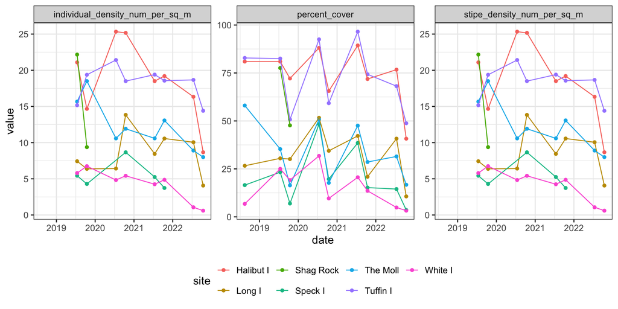

```r
kelptime_study_measurement_long <-
  kelptime_study |>
  tidyr::pivot_longer(cols =biomass_kg_wet_per_sq_m:percent_cover) |>
  filter(!is.na(value))

ggplot(kelptime_study_measurement_long,
       aes(x = date, y = value,
           color = site)) +
  geom_point() +
  geom_line() +
  facet_wrap(vars(name), scale = "free_y")
```

### 2.2 Standardized data

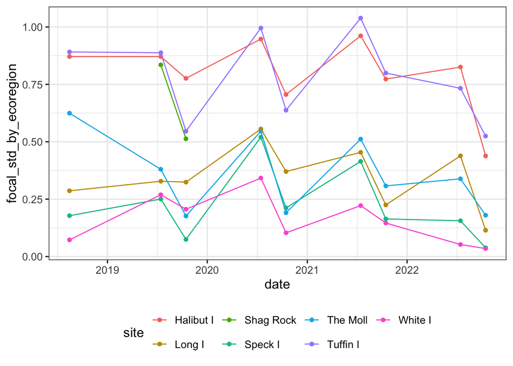

```r
ggplot(kelptime_study,
       aes(x = date, y = focal_std_by_ecoregion,
           color = site)) +
  geom_point() +
  geom_line()
```

### 2.3 Standardized data by site

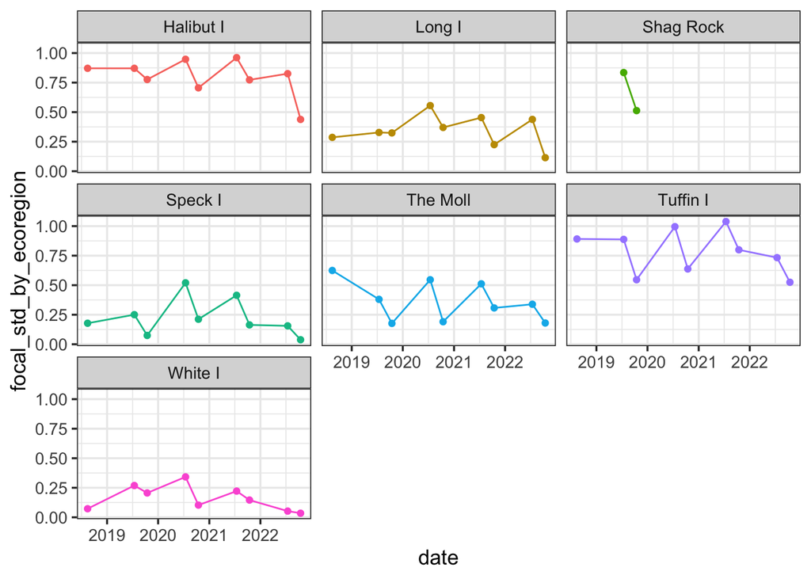

```r
ggplot(kelptime_study,
       aes(x = date, y = focal_std_by_ecoregion,
           color = site)) +
  geom_point() +
  geom_line() +
  facet_wrap(vars(site)) +
  guides(color = "none")
```

## 3. Modeled timeseries resuls

We fit two models. One where the slope varies by ecoregion (note: the GOSL and Newfoundland are collapsed) and one where the slope does not vary by ecoregion. Based on the modeled results, here is the smoothed fits to your data. Note - thus far, the model with a common slope appears to be the correct is the one with a common slope (best fit in terms of prediction and p-value for slope*ecoregion is not distinguishable from 0).

**Note** - the study (black) line might not line up in the middle or on trajectories, as it is shrunken in towards the grand mean for the ecoregion.

### 3.1 Slope Varying by Ecoregion Model

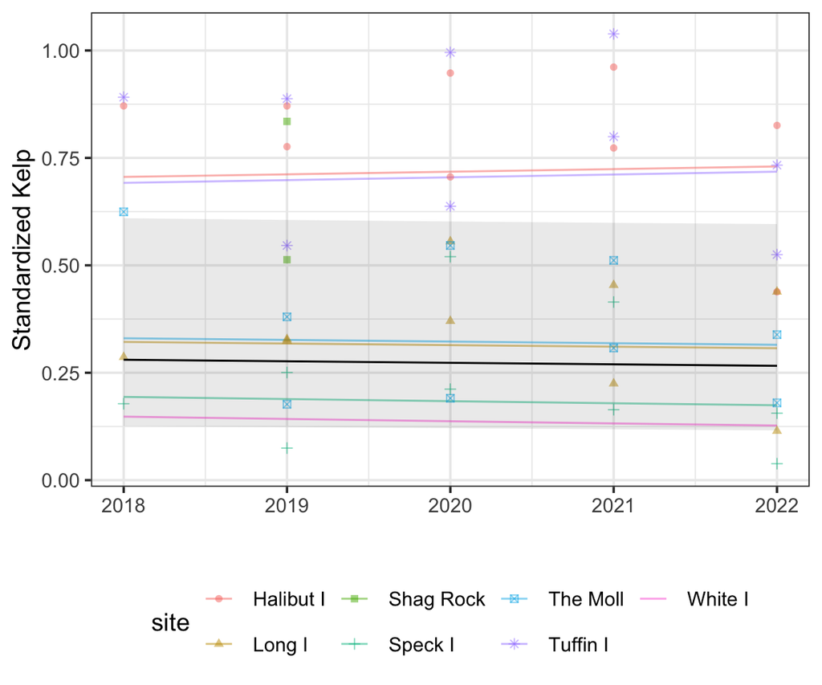

```r
mod_ecoregion <- readRDS("models/mod_ecoregion.rds")


# for plotting to do the back transform
exp_trans <- function(dat){

  dat |>
    mutate(
      Predicted = exp(Predicted)-0.01,
           CI_low = exp(CI_low)-0.01,
           CI_high = exp(CI_high)-0.01,
           CI_high = ifelse(CI_high>1.1, 1.1, CI_high)
    )|>
               mutate(trajectory =
                        gsub(study[1], "", trajectory))

}


re_ecoregion <- ranef(mod_ecoregion)$cond$study |>
  as_tibble(rownames = "study")  |>
  filter(study == params$study) |>
  pull(`(Intercept)`)


dat_fixed_ecoregion <- estimate_relation(mod_ecoregion,
                               include_random = FALSE,
                  length = 200,
                  data = kelptime_study) |>
  mutate(Predicted = Predicted + re_ecoregion,
         CI_high = CI_high + re_ecoregion,
         CI_low = CI_low + re_ecoregion) |>
  exp_trans()

dat_traj_ecoregion <- estimate_relation(mod_ecoregion,
                              include_random = TRUE,
                  length = 200,
                  data = kelptime_study) |>
    exp_trans()


ggplot(dat_traj_ecoregion, aes(x = year)) +
  geom_line(aes(y = Predicted,
                color = trajectory), alpha = 0.5) +
  geom_point(aes(y = focal_std_by_ecoregion,
                 group = trajectory,
                 shape = trajectory,
                 color = trajectory), alpha = 0.5,
             data = kelptime_study |>
               mutate(trajectory =
                        gsub(study[1], "", trajectory))) +
  geom_line(data = dat_fixed_ecoregion,
            aes(y = Predicted), color = "black") +
  geom_ribbon(data = dat_fixed_ecoregion,
            aes(y = Predicted,
                ymin = CI_low,
                ymax = CI_high), color = NA,
            alpha = 0.1) +
  labs(x = "", y = "Standardized Kelp",
      color = "site", shape = "site")
```

### 3.2 Common Slope Model

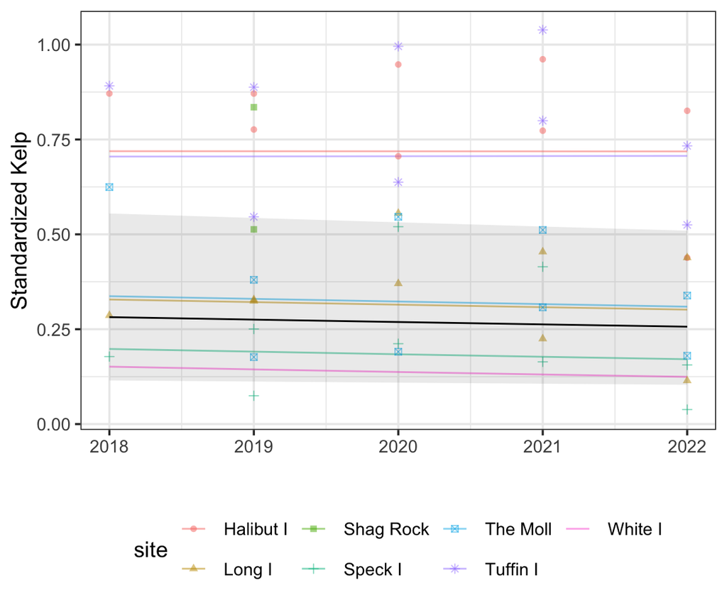

```r
mod_common_slope <- readRDS("models/mod_common_slope.rds")

re <- ranef(mod_common_slope)$cond$study |>
  as_tibble(rownames = "study")  |>
  filter(study == params$study) |>
  pull(`(Intercept)`)


dat_fixed <- estimate_relation(mod_common_slope,
                               include_random = FALSE,
                  length = 200,
                  data = kelptime_study) |>
  mutate(Predicted = Predicted + re,
         CI_high = CI_high + re_ecoregion,
         CI_low = CI_low + re_ecoregion) |>
  exp_trans()

dat_traj <- estimate_relation(mod_common_slope,
                              include_random = TRUE,
                  length = 200,
                  data = kelptime_study) |>
    exp_trans()

ggplot(dat_traj, aes(x = year)) +
  geom_line(aes(y = Predicted,
                color = trajectory), alpha = 0.5) +
  geom_point(aes(y = focal_std_by_ecoregion,
                 group = trajectory,
                 shape = trajectory,
                 color = trajectory), alpha = 0.5,
             data = kelptime_study |>
               mutate(trajectory =
                        gsub(study[1], "", trajectory))) +
  geom_line(data = dat_fixed,
            aes(y = Predicted), color = "black") +
  geom_ribbon(data = dat_fixed,
            aes(y = Predicted,
                ymin = CI_low,
                ymax = CI_high), color = NA,
            alpha = 0.1) +
  labs(x = "", y = "Standardized Kelp",
      color = "site", shape = "site")
```